# 02_HW_Sampling_Simulation

Hannah Stroud

September 14, 2018

# Sampling and Simulation

```r
library(dplyr)
library(magrittr)
```

### 1. R Warmup

#### 1a. Create a vector of 100 randomly distrubuted numbers

```r
   my_vec <- runif(100, min=0, max=100)
      str(my_vec)
```

```
##  num [1:100] 37.8 36.8 14.4 95.6 63 ...
```

```r
      summary(my_vec)
```

```
##    Min. 1st Qu.  Median    Mean 3rd Qu.    Max.
##  0.5673 34.7582 53.7597 54.7191 77.9337 99.7865
```

str gives information on the vector itself so tells you its a numeric vector and the number of elements  
summary gives information about the values in the vector- so it gives the Min, Max, Median and quartiles.

#### 1b. Plotting with hist

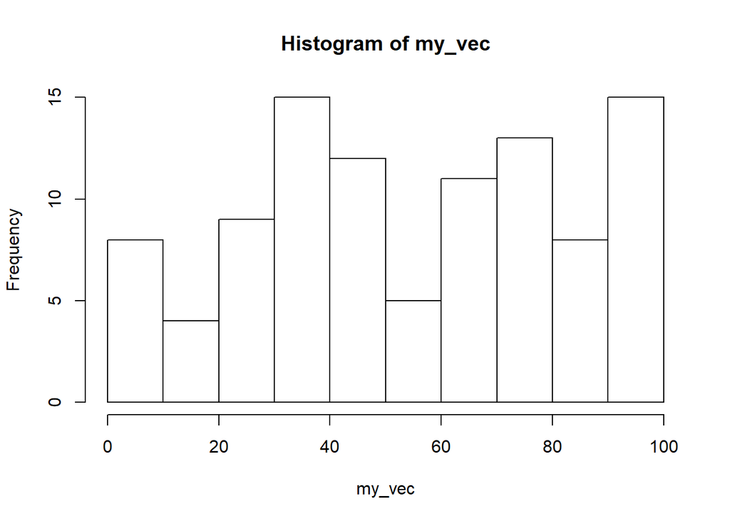

```r
hist(my_vec)
```

hist(my_vec) plots the frequency of each bin, with a bin size of 10 The helpfile gives the default arguments if all you enter in the () is the vector, and defines each parameter argument.

#### 1c. mtcars

```r
 data(mtcars)
    class(mtcars)
```

```
## [1] "data.frame"
```

```r
    str(mtcars)
```

```
## 'data.frame':    32 obs. of  11 variables:
##  $ mpg : num  21 21 22.8 21.4 18.7 18.1 14.3 24.4 22.8 19.2 ...
##  $ cyl : num  6 6 4 6 8 6 8 4 4 6 ...
##  $ disp: num  160 160 108 258 360 ...
##  $ hp  : num  110 110 93 110 175 105 245 62 95 123 ...
##  $ drat: num  3.9 3.9 3.85 3.08 3.15 2.76 3.21 3.69 3.92 3.92 ...
##  $ wt  : num  2.62 2.88 2.32 3.21 3.44 ...
##  $ qsec: num  16.5 17 18.6 19.4 17 ...
##  $ vs  : num  0 0 1 1 0 1 0 1 1 1 ...
##  $ am  : num  1 1 1 0 0 0 0 0 0 0 ...
##  $ gear: num  4 4 4 3 3 3 3 4 4 4 ...
##  $ carb: num  4 4 1 1 2 1 4 2 2 4 ...
```

```r
    summary(mtcars)
```

```
##       mpg             cyl             disp             hp
##  Min.   :10.40   Min.   :4.000   Min.   : 71.1   Min.   : 52.0
##  1st Qu.:15.43   1st Qu.:4.000   1st Qu.:120.8   1st Qu.: 96.5
##  Median :19.20   Median :6.000   Median :196.3   Median :123.0
##  Mean   :20.09   Mean   :6.188   Mean   :230.7   Mean   :146.7
##  3rd Qu.:22.80   3rd Qu.:8.000   3rd Qu.:326.0   3rd Qu.:180.0
##  Max.   :33.90   Max.   :8.000   Max.   :472.0   Max.   :335.0
##       drat             wt             qsec             vs
##  Min.   :2.760   Min.   :1.513   Min.   :14.50   Min.   :0.0000
##  1st Qu.:3.080   1st Qu.:2.581   1st Qu.:16.89   1st Qu.:0.0000
##  Median :3.695   Median :3.325   Median :17.71   Median :0.0000
##  Mean   :3.597   Mean   :3.217   Mean   :17.85   Mean   :0.4375
##  3rd Qu.:3.920   3rd Qu.:3.610   3rd Qu.:18.90   3rd Qu.:1.0000
##  Max.   :4.930   Max.   :5.424   Max.   :22.90   Max.   :1.0000
##        am              gear            carb
##  Min.   :0.0000   Min.   :3.000   Min.   :1.000
##  1st Qu.:0.0000   1st Qu.:3.000   1st Qu.:2.000
##  Median :0.0000   Median :4.000   Median :2.000
##  Mean   :0.4062   Mean   :3.688   Mean   :2.812
##  3rd Qu.:1.0000   3rd Qu.:4.000   3rd Qu.:4.000
##  Max.   :1.0000   Max.   :5.000   Max.   :8.000
```

class tells use mtcars is a data frame, str gives information about the dataframe- ie variables and number of observations, summary gives quartiles of each variable

### 2. Sample Properties

```r
vole_vaso <- c(98,96,94,88,86,82,77,74,70,60,
               59,52,50,47,40,35,29,13,6,5)
```

#### 2a. Say vole vasopressin 10 times fast as you can

```
I tripped up twice
```

#### 2b.

```r
     #mean
      mean(vole_vaso)
```

```
## [1] 58.05
```

```r
     #median
      median(vole_vaso)
```

```
## [1] 59.5
```

```r
     #standard deviation
      sd(vole_vaso)
```

```
## [1] 29.75244
```

```r
     #interquartile range
      IQR(vole_vaso)
```

```
## [1] 44.25
```

#### 2c. Standard Error of Mean

```r
       sem <- sd(vole_vaso)/sqrt(length(vole_vaso))
      sem
```

```
## [1] 6.652849
```

#### 2d.

The standard error of mean tells us that our mean is fairly precise for giving the average level of vassopressin in the population.

### 3. Sample Size for upper quartiles

```r
quantile(vole_vaso, probs = 0.75)
```

```
## 75%
##  83
```

#### 3b.Build Initial Data Frame

```r
vole_sim <- data.frame(samp_size= rep(5:20, time=100))
```

#### 3c. Simulate upper quartiles for each sample size

```r
vole_sim_uq <- vole_sim %>%
  rowwise() %>%
mutate(upp_qnt= quantile(sample(vole_vaso, size=samp_size, replace=TRUE),probs=0.75))
```

#### 3d. Plot to estimate best sample size

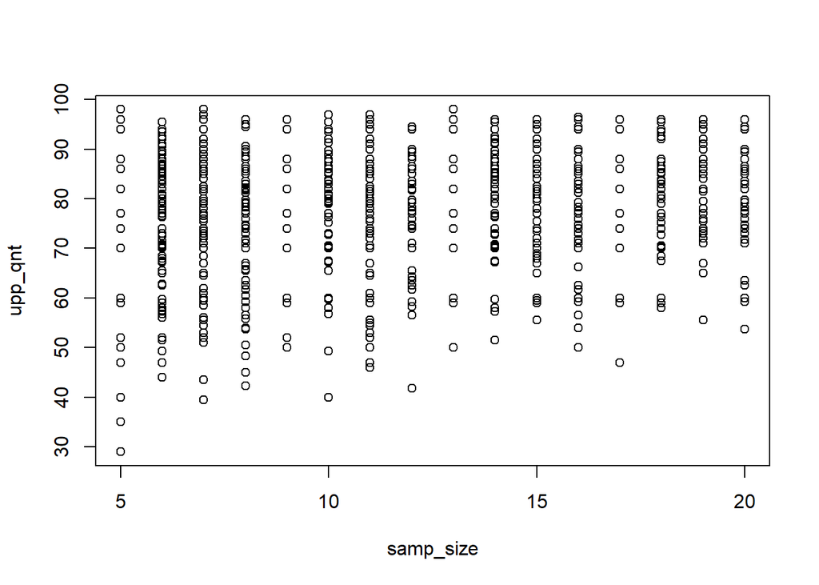

```r
plot(upp_qnt~samp_size, data=vole_sim_uq)
```

Best sample size would be around 17 samples.

### 4. SE and CI

#### 4a.

```r
stnd_err_upper_quant <- vole_sim_uq %>%
  group_by(samp_size)%>%
  summarize(sd_up_qnt= sd(upp_qnt), avg_upp_quant= mean(upp_qnt)) %>%
  ungroup()
```

#### 4b.The meaning of the standard error

```r
stderr_10 <- stnd_err_upper_quant[6,2]
avg_u_qt_10 <-stnd_err_upper_quant[6,3]
CI_10 <- 2*stderr_10
CI_uq_lower <- 83- stderr_10*2
CI_uq_upper <- 83+ stderr_10*2
```

#### 4d. Extra Credit Extra Credit: Instead of having each sim calculate a upper quartile, and then sifting down to the SE of that upper quartile (or the CI), have each simulation calculate a CI. Then, for just a sample size of 10, how many CI’s contain the true value of 83?

```r
# simulation that directly gives CI
# CI= 2*Standard Error
# standard error= standard deviation of your estimates
# standard deviation= measure of dispersion

vole_sim_CI <- vole_sim_uq %>% #take the upper quartile data already have
  group_by(samp_size)%>%
  summarize(uq_se = sd(upp_qnt), uq_avg= mean(upp_qnt)) %>%
  mutate(CI= 2*uq_se) %>%
  ungroup()
vole_sim_CI
```

```
## # A tibble: 16 x 4
##    samp_size uq_se uq_avg    CI
##        <int> <dbl>  <dbl> <dbl>
##  1         5 14.2    74.2  28.4
##  2         6 12.7    75.6  25.4
##  3         7 12.5    76.1  25.0
##  4         8 12.4    77.1  24.9
##  5         9 11.4    77    22.8
##  6        10 10.6    79.8  21.1
##  7        11 12.4    76.8  24.7
##  8        12  9.72   79.6  19.4
##  9        13 10.8    80.0  21.6
## 10        14  9.17   80.5  18.3
## 11        15  9.48   80.1  19.0
## 12        16  9.35   80.3  18.7
## 13        17  9.69   81.2  19.4
## 14        18  8.99   80.6  18.0
## 15        19  7.21   82.0  14.4
## 16        20  7.62   81.3  15.2
```